# Selecció de variables

Antonio Miñarro (aminarro@ub.edu)

17 desembre, 2022

# 1 Selecció de variables

- Una selecció acurada de les variables que intervenen en un model de regressió pot millorar la precisió del model.
- Afegir un excés de variables pot portar a un sobre-ajust (*overfitting*) amb un pobre poder predictiu sobre noves dades.
- És molt freqüent que no vulguem utilitzar com a variables predictores d’un model **totes** les disponibles, potser el nombre és molt gran. Per exemple podem tenir dades d’expressió gènica a partir d’un microarray de ADN amb més de 5000 gens!
- També és molt freqüent que en aquest tipus d’experiments la mida de la mostra (el número d’individus) sigui menor que el número de variables i sabem que això pot provocar problemes matemàtics en l’obtenció dels estimadors mínims quadràtics.
- L’obtenció de models amb un número reduït però suficient de variables predictores (**selecció de variables**) és per tant una tècnica desitjable i necessària.

## 1.1 Selecció de variables per la funció *step*

Hi ha [controversia](http://en.wikipedia.org/wiki/Stepwise_regression) entre els estadístics sobre la conveniència d’aplicar tècniques per seleccionar de format automàtica (forward, backward, etc.) subconjunts de variables predictores. Poden presentar-se problemes degut al gran número de tests realitzats. De totes maneres presentem la tècnica implementada per la funció **step** de R. També podeu consultar articles sobre la [Navalla d’Occam](http://ca.wikipedia.org/wiki/Navalla_d%27Occam).

La mesura utilitzada per quantificar la bondat del model és el [criteri d’informació de Akaike (AIC)](http://en.wikipedia.org/wiki/Akaike_information_criterion). Donat un conjunt de models candidats, el model preferit és el de menor AIC.

### 1.1.1 Selecció stepwise per les dades del càncer de pròstata

Aquest conjunt de dades està inclòs al package **genridge**. Les dades provenen d’un estudi que va examinar la correlació entre el nivell d’antigen específic de la pròstata i una sèrie de mesures clíniques en homes que estaven a punt de rebre una prostatectomia radical.

-lcavol: log(cancer volume) en cc

-lweight: log(prostate weight) logaritme del pes en grams

-age: edat en anys

-lbph: log(benign prostatic hyperplasia amount)

-svi: seminal vesicle invasion **(aquesta variable dicotòmica (0|1) serà eliminada d’aquesta anàlisi)**

-lcp: log(capsular penetration)

-gleason: Gleason score

-pgg45: percentage Gleason scores 4 or 5

-lpsa: log(prostate specific antigen) logaritme de psa en ng per ml.

-train: **variable auxiliar eliminada d’aquesta anàlisi**

**L’objectiu és verificar la influència de diverses variables sobre el valor del psa (lpsa)**.

### 1.1.2 Càrrega i visualització de les dades

```r
library(genridge)
data("prostate")
prostate<-prostate[,-c(5,10)]
head(prostate)
```

| lcavol | lweight | age | lbph | lcp | gleason | pgg45 | lpsa |
| --- | --- | --- | --- | --- | --- | --- | --- |
| -0.5798185 | 2.769459 | 50 | -1.386294 | -1.386294 | 6 | 0 | -0.4307829 |
| -0.9942523 | 3.319626 | 58 | -1.386294 | -1.386294 | 6 | 0 | -0.1625189 |
| -0.5108256 | 2.691243 | 74 | -1.386294 | -1.386294 | 7 | 20 | -0.1625189 |
| -1.2039728 | 3.282789 | 58 | -1.386294 | -1.386294 | 6 | 0 | -0.1625189 |
| 0.7514161 | 3.432373 | 62 | -1.386294 | -1.386294 | 6 | 0 | 0.3715636 |
| -1.0498221 | 3.228826 | 50 | -1.386294 | -1.386294 | 6 | 0 | 0.7654678 |

```r
prostate.lm.full<-lm(lpsa~.,data=prostate)
step(prostate.lm.full)
```

```
## Start:  AIC=-52.36
## lpsa ~ lcavol + lweight + age + lbph + lcp + gleason + pgg45
##
##           Df Sum of Sq    RSS     AIC
## - gleason  1    0.0022 47.941 -54.360
## - lcp      1    0.0115 47.950 -54.341
## - lbph     1    0.7153 48.654 -52.928
## <none>                 47.939 -52.364
## - pgg45    1    1.0022 48.941 -52.357
## - age      1    1.5752 49.514 -51.228
## - lweight  1    5.4232 53.362 -43.969
## - lcavol   1   23.7874 71.726 -15.280
##
## Step:  AIC=-54.36
## lpsa ~ lcavol + lweight + age + lbph + lcp + pgg45
##
##           Df Sum of Sq    RSS     AIC
## - lcp      1    0.0116 47.953 -56.336
## - lbph     1    0.7131 48.654 -54.928
## <none>                 47.941 -54.360
## - pgg45    1    1.5377 49.479 -53.298
## - age      1    1.5993 49.540 -53.177
## - lweight  1    5.5441 53.485 -45.745
## - lcavol   1   24.4326 72.374 -16.408
##
## Step:  AIC=-56.34
## lpsa ~ lcavol + lweight + age + lbph + pgg45
##
##           Df Sum of Sq    RSS     AIC
## - lbph     1     0.707 48.659 -56.917
## <none>                 47.953 -56.336
## - age      1     1.676 49.629 -55.004
## - pgg45    1     2.335 50.288 -53.724
## - lweight  1     5.570 53.522 -47.678
## - lcavol   1    36.856 84.809  -3.029
##
## Step:  AIC=-56.92
## lpsa ~ lcavol + lweight + age + pgg45
##
##           Df Sum of Sq    RSS     AIC
## <none>                 48.659 -56.917
## - age      1     1.267 49.926 -56.424
## - pgg45    1     2.437 51.097 -54.176
## - lweight  1     8.509 57.169 -43.284
## - lcavol   1    36.158 84.817  -5.019
```

```
##
## Call:
## lm(formula = lpsa ~ lcavol + lweight + age + pgg45, data = prostate)
##
## Coefficients:
## (Intercept)       lcavol      lweight          age        pgg45
##   -0.167077     0.599071     0.762844    -0.017040     0.006426
```

Podem fer que la selecció es faci introduint variables en lloc d’eliminar-les

```r
prostate.lm.null<-lm(lpsa~1,data=prostate)
prostate.step<-step(prostate.lm.null,scope=list(upper=prostate.lm.full),direction='forward')
```

```
## Start:  AIC=28.84
## lpsa ~ 1
##
##           Df Sum of Sq     RSS     AIC
## + lcavol   1    69.003  58.915 -44.366
## + lcp      1    38.528  89.389  -3.926
## + lweight  1    24.019 103.899  10.665
## + pgg45    1    22.814 105.103  11.783
## + gleason  1    17.416 110.502  16.641
## + lbph     1     4.136 123.782  27.650
## + age      1     3.679 124.239  28.007
## <none>                 127.918  28.838
##
## Step:  AIC=-44.37
## lpsa ~ lcavol
##
##           Df Sum of Sq    RSS     AIC
## + lweight  1    7.1726 51.742 -54.958
## + lbph     1    3.2658 55.649 -47.898
## + pgg45    1    1.6980 57.217 -45.203
## <none>                 58.915 -44.366
## + lcp      1    0.6562 58.259 -43.452
## + gleason  1    0.4156 58.499 -43.053
## + age      1    0.0025 58.912 -42.370
##
## Step:  AIC=-54.96
## lpsa ~ lcavol + lweight
##
##           Df Sum of Sq    RSS     AIC
## + pgg45    1   1.81577 49.926 -56.424
## <none>                 51.742 -54.958
## + lcp      1   0.81872 50.923 -54.506
## + gleason  1   0.71630 51.026 -54.311
## + age      1   0.64564 51.097 -54.176
## + lbph     1   0.44404 51.298 -53.794
##
## Step:  AIC=-56.42
## lpsa ~ lcavol + lweight + pgg45
##
##           Df Sum of Sq    RSS     AIC
## + age      1   1.26709 48.659 -56.917
## <none>                 49.926 -56.424
## + lbph     1   0.29763 49.629 -55.004
## + lcp      1   0.06441 49.862 -54.549
## + gleason  1   0.01595 49.910 -54.455
##
## Step:  AIC=-56.92
## lpsa ~ lcavol + lweight + pgg45 + age
##
##           Df Sum of Sq    RSS     AIC
## <none>                 48.659 -56.917
## + lbph     1   0.70678 47.953 -56.336
## + lcp      1   0.00530 48.654 -54.928
## + gleason  1   0.00000 48.659 -54.917
```

```r
summary(prostate.step)
```

```
##
## Call:
## lm(formula = lpsa ~ lcavol + lweight + pgg45 + age, data = prostate)
##
## Residuals:
##      Min       1Q   Median       3Q      Max
## -1.47339 -0.41884 -0.04077  0.41314  1.79950
##
## Coefficients:
##              Estimate Std. Error t value Pr(>|t|)
## (Intercept) -0.167077   0.793069  -0.211 0.833609
## lcavol       0.599071   0.072455   8.268 9.94e-13 ***
## lweight      0.762844   0.190184   4.011 0.000123 ***
## pgg45        0.006426   0.002994   2.147 0.034453 *
## age         -0.017040   0.011009  -1.548 0.125104
## ---
## Signif. codes:  0 '***' 0.001 '**' 0.01 '*' 0.05 '.' 0.1 ' ' 1
##
## Residual standard error: 0.7273 on 92 degrees of freedom
## Multiple R-squared:  0.6196, Adjusted R-squared:  0.6031
## F-statistic: 37.46 on 4 and 92 DF,  p-value: < 2.2e-16
```

Comparem el resultat obtingut amb el model complet

```r
summary(prostate.lm.full)
```

```
##
## Call:
## lm(formula = lpsa ~ ., data = prostate)
##
## Residuals:
##      Min       1Q   Median       3Q      Max
## -1.45732 -0.40002 -0.03143  0.41678  1.80254
##
## Coefficients:
##              Estimate Std. Error t value Pr(>|t|)
## (Intercept)  0.422836   1.383227   0.306  0.76056
## lcavol       0.605602   0.091130   6.645 2.34e-09 ***
## lweight      0.667132   0.210248   3.173  0.00207 **
## age         -0.019872   0.011620  -1.710  0.09073 .
## lbph         0.069226   0.060072   1.152  0.25225
## lcp          0.012516   0.085668   0.146  0.88417
## gleason     -0.010314   0.161779  -0.064  0.94931
## pgg45        0.006198   0.004543   1.364  0.17599
## ---
## Signif. codes:  0 '***' 0.001 '**' 0.01 '*' 0.05 '.' 0.1 ' ' 1
##
## Residual standard error: 0.7339 on 89 degrees of freedom
## Multiple R-squared:  0.6252, Adjusted R-squared:  0.5958
## F-statistic: 21.21 on 7 and 89 DF,  p-value: < 2.2e-16
```

## 1.2 Tècniques de regularització

A estadística parlem de **regularització** com un procés d’introducció d’informació addicional (posiblement en forma de penalització) per ajudar a resoldre un problema mal definit o evitar el sobre-ajust (overfitting)

Comencem considerant un ajust lineal ordinari.

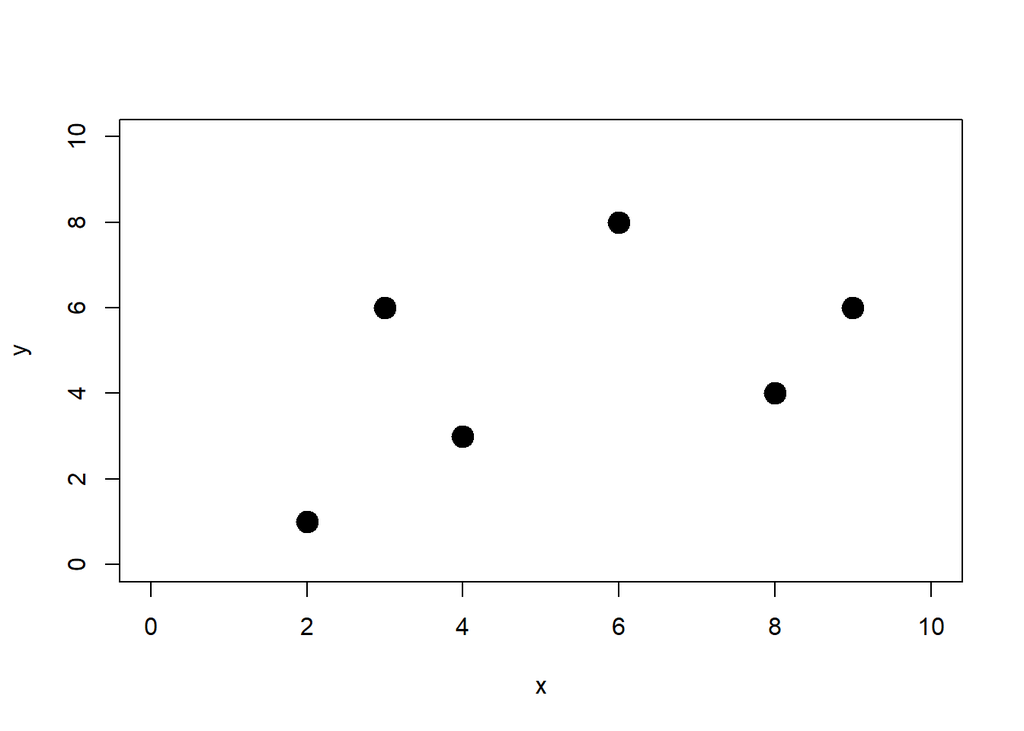

La recta de regressió lineal proporciona el millor ajust lineal minimitzant la suma dels quadrats dels errors (SSE)

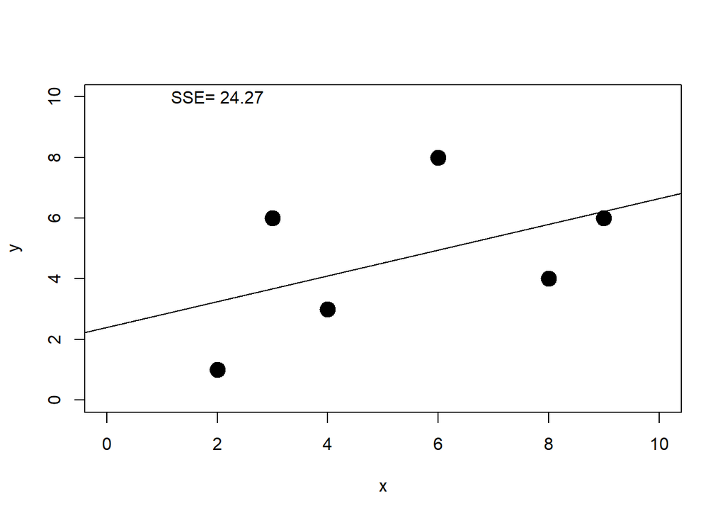

Imaginem que només disposem de dos punts, per exemple els dos primers

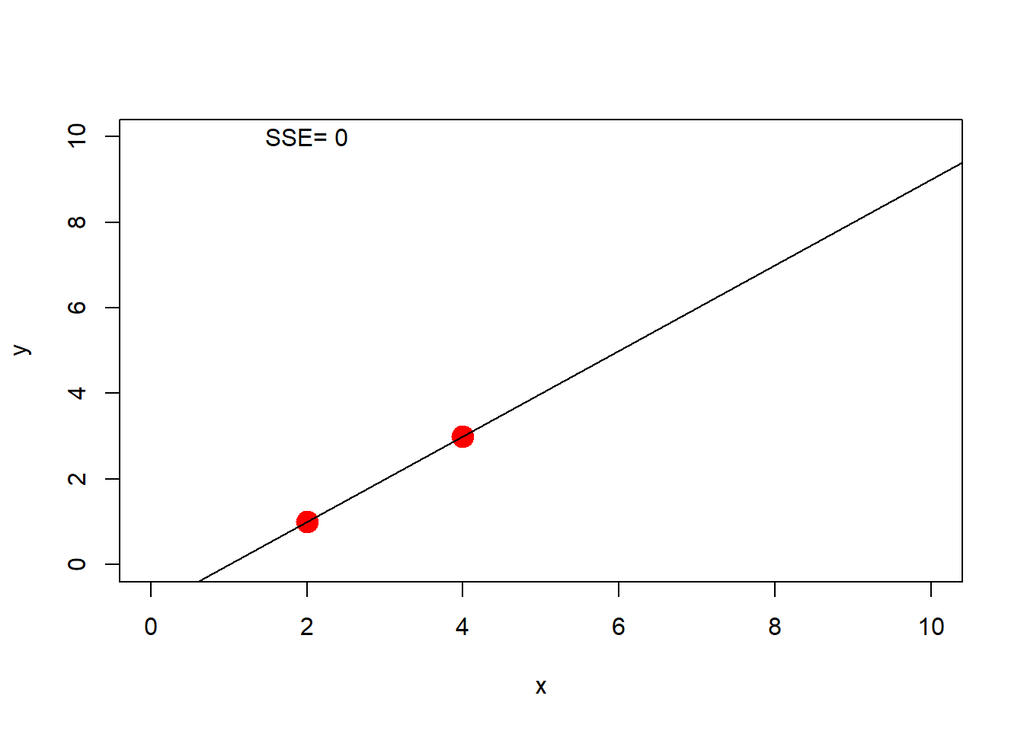

L’ajust lineal és perfecte SSE=0.

Però que passa si volem aplicar aquesta recta a noves observacions i mirem l’ajust dels punts

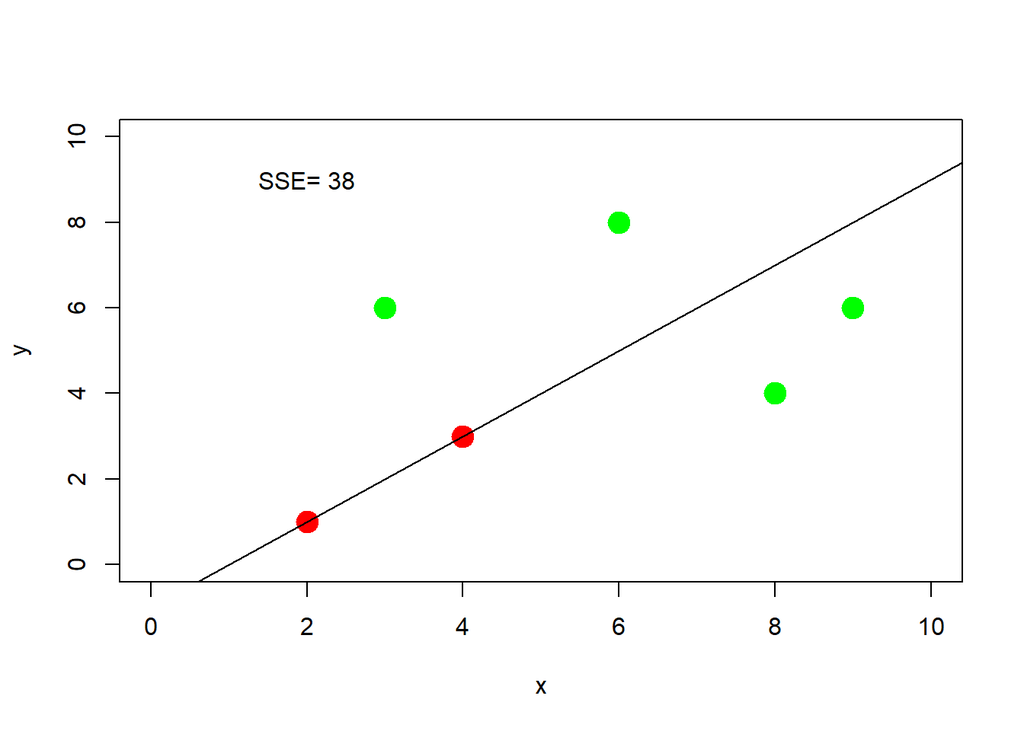

La suma dels errors, lógicament, és pitjor que al principi. Però aquesta és una situació en que ens trobem molt sovint, mostres petites a les que fem un ajust molt bo però que no es comporten bé amb noves observacions (perill de sobre-ajust).

A través d’algunes tècniques de regularització s’intenta cercar un millor ajust per noves observacions tot i que és penalitzi l’ajust per les observacions que componen la mostra d’entrenament.

Una d’aquestes tècniques penalitza el pendent de la recta, fent que aquesta tendeixi a valors més petits i per tant la recta a ser més horitzontal. Una recta molt vertical és molt perillosa, els errors es disparen ràpidament.

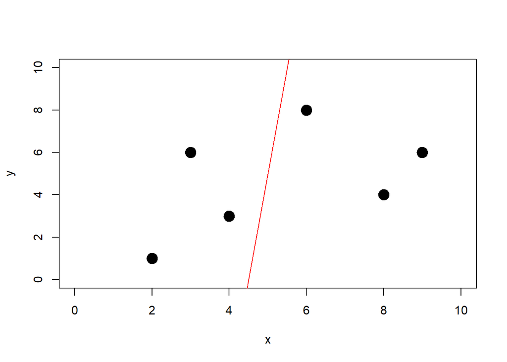

Una possible penalització adopta la forma: $\lambda \cdot slope^2$. Per tant el que es vol minimitzar per determinar la millor recta és
$$SSE+\lambda \cdot slope^2$$
$\lambda$ és un paràmetre, anomenat **paràmetre de contracció** (*shrinkage parameter*), que controla la força de la penalització. Si $\lambda=0$ tenim la regressió lineal ordinaria on minimitzem només $SSE$, a mesura que $\lambda$ s’incrementa cada cop penalitzem més i en el límit tindríem com a única opció una recta horitzontal (pendent = 0) que equival a dir que la variable predictora desapareix del model.

Tornem a considerar el cas en que tenim dos punts per construir el model

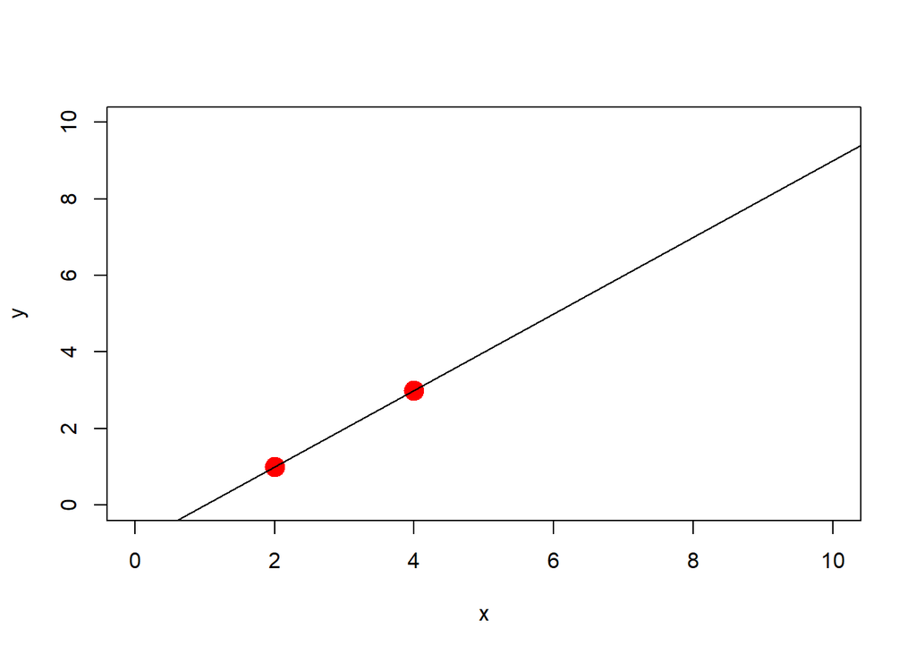

La millor recta és $Y=$ -1 + 1 $\cdot X$ amb SSE=0.

Però anem a construir altres rectes amb altres pendents i calculem per a elles $SSE+P=SSE+\lambda \cdot slope^2$ mantenint $\lambda=1$.

$\lambda$=1

| Pendent | SSEP |
| --- | --- |
| 1.5 | 2.75 |
| 1.4 | 2.28 |
| 1.3 | 1.87 |
| 1.2 | 1.52 |
| 1.1 | 1.23 |
| 1.0 | 1.00 |
| 0.9 | 0.83 |
| 0.8 | 0.72 |
| 0.7 | 0.67 |
| 0.6 | 0.68 |
| 0.5 | 0.75 |
| 0.4 | 0.88 |
| 0.3 | 1.07 |
| 0.2 | 1.32 |

Aparentment la millor recta seria la de pendent = 0.7. Dibuixem-la

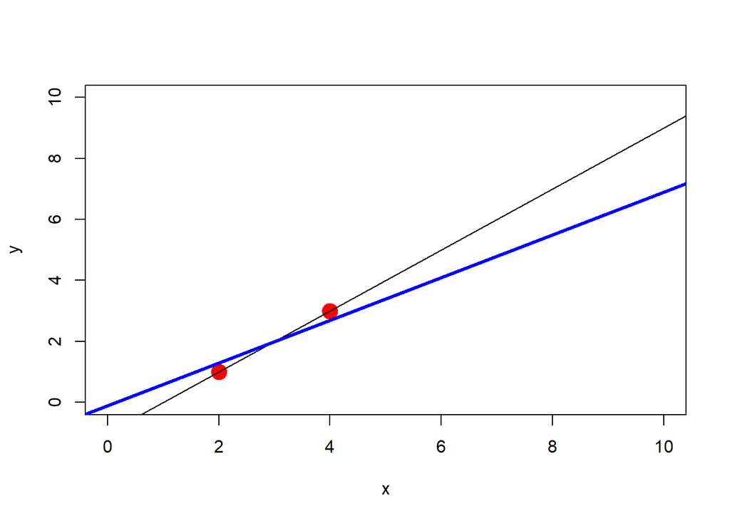

Evidentment ens queda el problema de determinar la $\lambda$, el **paràmetre de contracció**. Veiem com una altra elecció de $\lambda$ proporciona resultats diferents

Valor de SSE+P

| Pendent | $\lambda$=0.5 | $\lambda$=0.05 | $\lambda$=10 |
| --- | --- | --- | --- |
| 1.5 | 1.625 | 0.6125 | 23.00 |
| 1.4 | 1.300 | 0.4180 | 19.92 |
| 1.3 | 1.025 | 0.2645 | 17.08 |
| 1.2 | 0.800 | 0.1520 | 14.48 |
| 1.1 | 0.625 | 0.0805 | 12.12 |
| 1.0 | 0.500 | 0.0500 | 10.00 |
| 0.9 | 0.425 | 0.0605 | 8.12 |
| 0.8 | 0.400 | 0.1120 | 6.48 |
| 0.7 | 0.425 | 0.2045 | 5.08 |
| 0.6 | 0.500 | 0.3380 | 3.92 |
| 0.5 | 0.625 | 0.5125 | 3.00 |
| 0.4 | 0.800 | 0.7280 | 2.32 |
| 0.3 | 1.025 | 0.9845 | 1.88 |
| 0.2 | 1.300 | 1.2820 | 1.68 |

Podem fer una gràfica on quedin il·lustrats aquests resultats

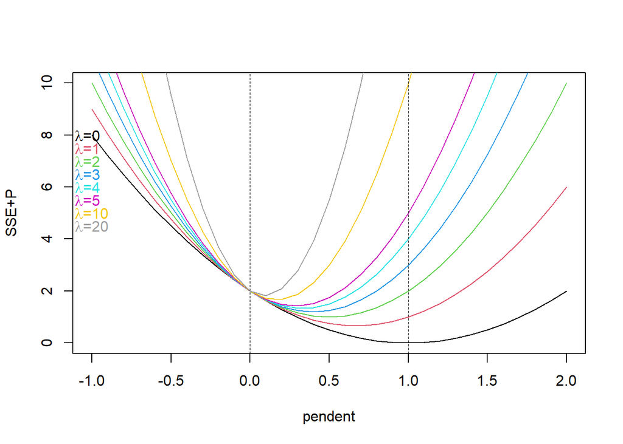

A mesura que s’incrementa $\lambda$ el pendent tendeix a ser més petit.

### 1.2.1 Ridge Regression

- Aquesta tècnica de regularització rep el nom de **Ridge Regression Estimator** i va ser proposada per Hoerl i Kennard.
- Si l’apliquem a un model de regressió múltiple, la penalització es transforma en la suma dels quadrats dels pendents de totes les variables predictores del model. El que llavors minimitzem és:

$$SSE + \lambda \sum_{j=1}^p \beta_j^2
= \sum_{i=1}^n (Y_i-(\beta_1 X_{i1}+ \beta_2 X_{i2}+ \cdots + \beta_p
X_{ip}))^2 + \lambda \sum_{j=1}^p \beta_j^2$$

- Tendeix a produir estimacions amb valors més petits dels coeficients.
- És necessari un procés acurat d’ajust (*tuning*) per triar el valor de $\lambda$ . La forma més utilitzada avui en dia és per **validació creuada** (*cross-validation*). Ho veurem més endavant.
- No és una tècnica de selecció completa de variables (*sparse*) perquè els coeficients no arriben a ser zero.
- Una gran avantatge és que permet treballar amb mostres més petites que el número de variables en el model.

## 1.3 Regressió **Lasso** (*l*east *a*bsolute *s*hrinkage and *s*election *o*perator)

- És una modificació de la **ridge regression** on la restricció en lloc de contemplar els pendents al quadrat contempla els valors absoluts dels pendents.
- A una regressió múltiple

$$SSE + \lambda \sum_{j=1}^p |\beta_j|
= \sum_{i=1}^n (Y_i-(\beta_1 X_{i1}+ \beta_2 X_{i2}+ \cdots + \beta_p
X_{ip}))^2 + \lambda \sum_{j=1}^p |\beta_j|$$

Anem a veure com es comporta l’estimació en un cas de regressió simple si la penalització és

$$SSE+P=SSE+\lambda \cdot
|slope|$$

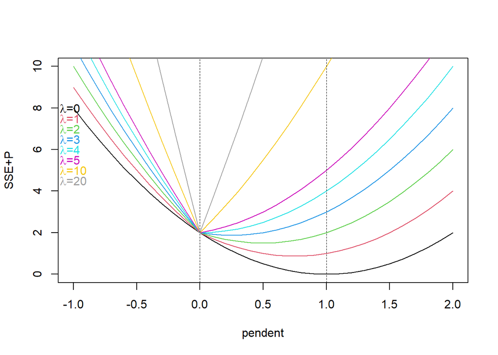

- En aquest cas sí que arriba un moment que la solució òptima es de pendent nul·la i per tant **la variable predictora desapareix del model**.
- És el que s’anomena una tècnica *sparse*, **simplifica el model eliminant variables predictores**.

### 1.3.1 Lasso vs. Ridge regression

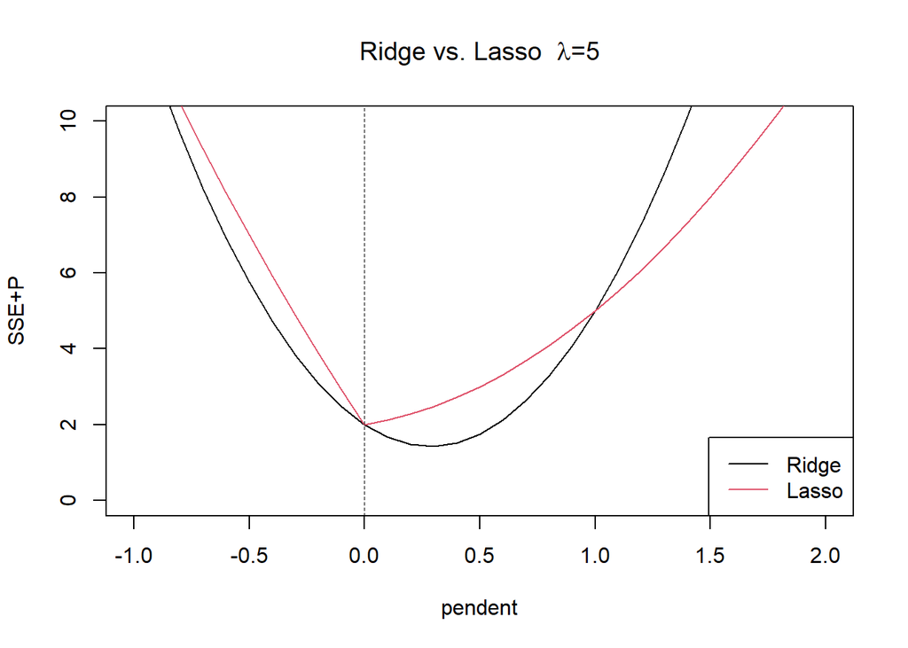

- A l’incrementar les dimensions amb la regularització per Lasso hi ha més probabilitat de que alguns coeficients siguin fixats a zero. D’aquesta forma s’efectua una autèntica selecció de variables.
- La solució analítica no existeix, s’han de fer servir tècniques i algorismes numèrics.

## 1.4 Determinació del paràmetre de contracció **paràmetre de contracció** (*shrinkage parameter*) per validació creuada (*Cross-validation tuning*)

- És un procés que podem demanar al software que ho faci de forma automàtica.

### 1.4.1 Validació creuada

1. Particionem el conjunt de dades T en K subconjunts ($T=(T_1,...,T_K)$) d’igual mida **Validació creuada *K-fold*** (Usualment K=10)
2. Per cada $i=1,2,...,K$ ajustem el model fent servir totes les dades excepte les de $T_i$.
3. Calculem els valors ajustats de les observacions de $T_i$ i l’error quadràtic.
4. Calculem l’error global

$$(CV Error)^\lambda = K^{-1} \sum_{i=1}^K
(CV Error)^\lambda_i$$

5. Seleccionem el valor de $\lambda^*$ que minimitza $(CV Error)^\lambda$.
6. Tornem a ajustar el model amb $\lambda^*$ sobre el total de la mostra.
- El cas extrem en que $K=N$ es coneix com a *leave-one-out cross validation (LOOCV)*.

## 1.5 Generalització de la funció penalitzadora (opcional)

- Es pot considerar una família de penalitzacions

$$P_\alpha=\sum_{j=1}^p [ (1-\alpha)
\beta_j^2 + \alpha |\beta_j| ] = \lambda_1 | \beta |_1 + \lambda_2 |
\beta|^2$$

on $0 \le \alpha \le 1$.

- La regressió ridge correspon a $\alpha=0$ i la regressió lasso a $\alpha=1$. Valors $0 < \alpha < 1$ es coneixen com mètode *elastic net*.
- La regressió ridge fa tendir tots els coeficients a valors petits mentre que la regressió lasso tendeix a anul·lar alguns coeficients i per tant donar una solució *sparse* (amb pocs elements).
- Existeix una versió agrupada (**grouped lasso**) Yuan and Lin (2007), que permet fer una selecció d’un grup de variables predictores. És útil per exemple si tenim una variable predictora categòrica amb més de dues categories.

## 1.6 Funcions de R per seleccionar variables per *ridge regression* i *lasso*.

- Utilitzarem les funcions *glmnet* i *cv.glmnet* del package **glmnet**.
- Crida i principals paràmetres
  - glmnet (x,y,alpha = 1,lambda=num)
    - x (Matriu amb variables predictores)
    - y (Vector amb variable resposta)
    - alpha (Paràmetre per seleccionar la penalització. La regressió ridge correspon a $\alpha=0$ i la regressió lasso a $\alpha=1$. )
    - lambda (valor numèric per $\lambda$ o seqüència per explorar)
  - cv.glmnet (x,y,alpha =0,nfolds=10)
    - nfolds (Número de subdivisions. Per defecte 10. Mínim 3. El número de mostres per LOOCV)

## 1.7 Lasso sobre les dades del conjunt **prostate**

- Dividirem en un conjunt d’entrenament i un de test, aproximadament un 50 % tot i que la mida mostral no és gaire gran.
- Separem variables predictores i variable resposta

```r
library(glmnet)
set.seed(2022)
train = sample(1:nrow(prostate), nrow(prostate)/2)
trainP<-prostate[train,]
testP<-prostate[-train,]


X<-as.matrix(trainP[,-8]) # Cal un format de matriu, no data.frame
Y<-trainP[,8]
X.test<-as.matrix(testP[,-8]) # Cal un format de matriu, no data.frame
Y.test<-testP[,8]
```

### 1.7.1 Determinació del millor paràmetre de selecció per CV

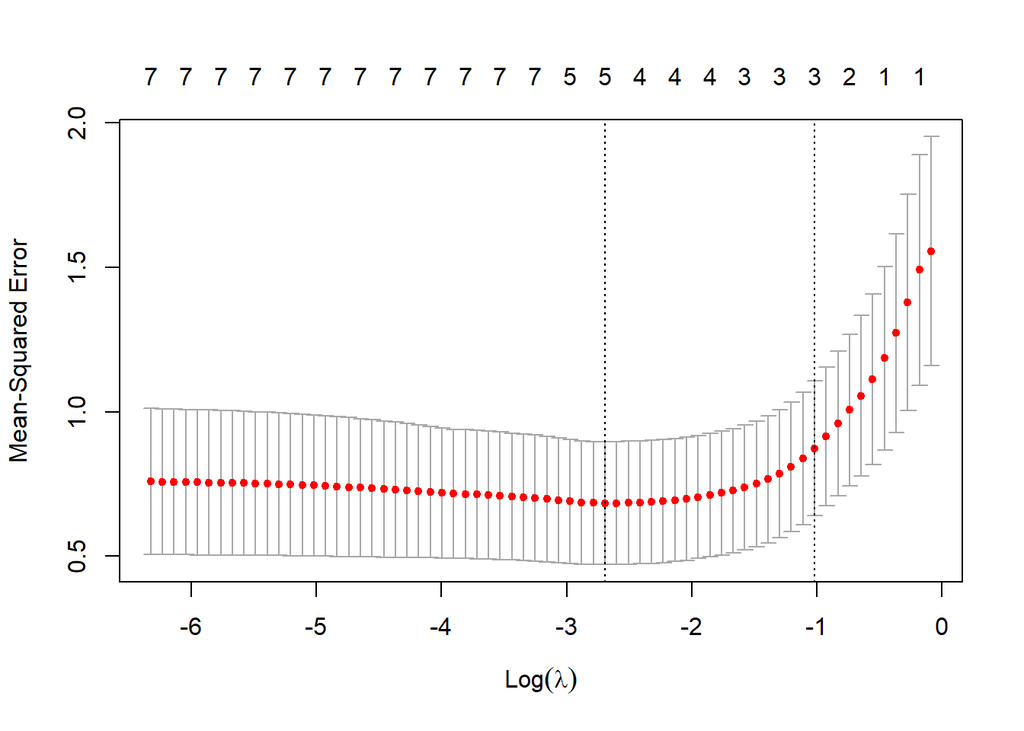

```r
cv_output <- cv.glmnet(X,Y,alpha = 1)
plot(cv_output)
```

#### 1.7.1.1 Valor de lambda que dona el mínim error en la validació creuada

```r
(best_lam <- cv_output$lambda.min)
```

```
## [1] 0.06762573
```

#### 1.7.1.2 Valor més gran de lambda tal que l’error és dintre d’una desviació típica del mínim

Generalmente produeix un model més simplificat que l’anterior

```r
(sparse_lam <- cv_output$lambda.1se)
```

```
## [1] 0.3608982
```

### 1.7.2 Reajust del model

```r
lasso_model <- glmnet(X,Y, alpha = 1)
coefficients(lasso_model,s=best_lam)
```

```
## 8 x 1 sparse Matrix of class "dgCMatrix"
##                       s1
## (Intercept) -1.101568072
## lcavol       0.461941076
## lweight      0.918161354
## age         -0.006001101
## lbph         .
## lcp          0.153820029
## gleason      .
## pgg45        0.003199214
```

```r
coefficients(lasso_model,s=sparse_lam)
```

```
## 8 x 1 sparse Matrix of class "dgCMatrix"
##                     s1
## (Intercept) 1.07045868
## lcavol      0.40119839
## lweight     0.25549064
## age         .
## lbph        .
## lcp         0.02775822
## gleason     .
## pgg45       .
```

### 1.7.3 Mesura de la bondat de les prediccions a través del MSE (mean square error)

```r
lasso_pred = predict(lasso_model, s = best_lam, newx = X.test)
mean((lasso_pred - Y.test)^2) # test MSE
```

```
## [1] 0.5896383
```

```r
lasso_pred = predict(lasso_model, s = sparse_lam, newx = X.test)
mean((lasso_pred - Y.test)^2) # test MSE
```

```
## [1] 0.6028456
```

#### 1.7.3.1 Comparació amb el model complet amb mínims quadrats

```r
lm_model<-lm(lpsa~.,trainP)
lm_pred<-predict(lm_model,newdata = testP)
mean((lm_pred - testP[,8])^2) # test MSE
```

```
## [1] 0.7530153
```